# HW2-Olbum

Orly Olbum

## Question 1

- *I provide MCMC data for the Senate dynamic model for the subset of data used in class (Northeast Senators; every 10th vote; dyn_senate.RDS). Using that output from MCMCpack please calculate the following quantities:*
  - *Who has the largest (absolute) change between any two periods? Present your result probabilistically, i.e. the senators with the largest probability of having the largest change. Hint: Note this is similar to how CJR present their probability of being a median senator (as we discussed last week).*

Since we are looking at differencing time periods, this will only apply to senators who have data collected for more than one time period. Arlen Specter switched to democrat after serving as a republican, so I will treat his t1 as a Dem as t4 for him overall.

```r
# take difference columns (excluded here for cleanliness)
dyn_sub = dyn_df[, grepl(colnames(dyn_df), pattern = '^diff')]
senator_diff = apply(dyn_sub, MARGIN = 1, FUN = function(i){
  names(sort(i)[24]) # 24 senators in the subset (???)
})
senator_diff = data.frame(table(senator_diff)) %>%
  arrange(desc(Freq))
senator_diff = senator_diff %>%
  mutate(pr = Freq/sum(Freq)) %>%
  arrange(desc(pr))
senator_diff
```

| senator_diff | Freq | pr |
| --- | --- | --- |
| diff.KERRY43 | 92 | 0.02300 |
| diff.SHAHEEN54 | 92 | 0.02300 |
| diff.SPECTER32 | 87 | 0.02175 |
| diff.COLLINS21 | 85 | 0.02125 |
| diff.COLLINS54 | 83 | 0.02075 |
| diff.KENNEDY21 | 82 | 0.02050 |
| diff.SNOWE21 | 82 | 0.02050 |
| diff.SNOWE43 | 82 | 0.02050 |
| diff.BLUMENTHAL45 | 81 | 0.02025 |
| diff.GILLIBRAND54 | 81 | 0.02025 |

[output cut: 50 more lines]

After differencing and taking the absolute value, we can see from the table that Senators Kerry and Shaheen are tied for first with most likely to have the largest difference between time points of this group of senators.

- *For all senators who served for at least two periods, calculate their average (absolute) change between each period. That is, define* $C_{i,t} = |x_{i,t} − x_{i,t−1}|$ *and* $\overline{C_{i}} = \sum_{t = 2}^{T} C_{i,t}$. *Present* $\overline{C_{i}}$ *for all senators who served at least two periods. Order members from smallest to largest and present the uncertainty in* $\overline{C_{i}}$.

We have $C_{i,t}$ from the differencing done above, so now we just need to sum over all data for each Senator with data measured for more than two time periods.

```r
# sums for each column
Ci_hat = dyn_sub %>%
  map_dbl(sum) %>%
  as.data.frame() %>%
  arrange(-desc(.))
colnames(Ci_hat) = 'Avg Change'
Ci_hat
```

|  | Avg Change |
| --- | --- |
| diff.COLLINS21 | 639.8692 |
| diff.COLLINS54 | 671.8403 |
| diff.SNOWE21 | 673.4927 |
| diff.SPECTER21 | 696.0154 |
| diff.LIEBERMAN32 | 710.2688 |
| diff.SNOWE43 | 742.5813 |
| diff.SPECTER32 | 788.1853 |
| diff.LIEBERMAN43 | 799.7980 |
| diff.SHAHEEN54 | 855.2710 |
| diff.CASEY43 | 865.3309 |

[output cut: 51 more lines]

I wasn’t entirely sure how to present uncertainty here - do I go back to the individual data to calculate, and incorporate as I aggregate by senator? Or is there a calculation I am missing? I’m definitely hazy on what uncertainty here would mean - so presenting the $\overline{C_{i}}$ on its own.

## Question 2

- *Using the Senate data on Canvas for the 109th-113th Senates (lecture/senate_rcv.RDS), please fit a dynamic IRT model for the entire dataset.*
  - *You are strongly encouraged to not use MCMC.*

```r
# function to turn votes into matrices before compiling

getmatrix = function(dataframe, time){

  # reconfigure vote codes
  dataframe[dataframe == 1 | dataframe == 2 | dataframe == 3] = 1
  dataframe[dataframe == 4 | dataframe == 5 | dataframe == 6] = -1
  dataframe[dataframe == 7 | dataframe == 8 | dataframe == 9] = 0
  dataframe[dataframe == 0] = 0

  # turn indexes into a column of senators
  dataframe = dataframe %>%
    rownames_to_column(var = 'Senator')

  # spread out the dataframe and omit NAs
  dataframe_update = dataframe %>%
    pivot_longer(-c(Senator), names_to = 'vote') %>%
    na.omit()

  # set up time for senate
  dataframe_update$time = time

  # change column names
  colnames(dataframe_update) = c('member', 'bill', 'vote', 'time')

  # join bill and time for identifier, will later turn into columns
  dataframe_update = dataframe_update %>%
    mutate(joint_id = paste(bill, time))

  # subset and get rid of unneeded columns
  dataframe_update = subset(dataframe_update, select = -c(bill, time))

  return(dataframe_update)
}
```

```r
senate1 = as.data.frame(senate_data[[1]]$votes)
senate1_update = getmatrix(senate1, 1)

senate2 = as.data.frame(senate_data[[2]]$votes)
senate2_update = getmatrix(senate2, 2)

senate3 = as.data.frame(senate_data[[3]]$votes)
senate3_update = getmatrix(senate3, 3)

senate4 = as.data.frame(senate_data[[4]]$votes)
senate4_update = getmatrix(senate4, 4)

senate5 = as.data.frame(senate_data[[5]]$votes)
senate5_update = getmatrix(senate5, 5)

senate_votes = rbind(senate1_update, senate2_update, senate3_update, senate4_update, senate5_update)
```

```r
senate_votes = senate_votes %>%
  reshape2::dcast(member ~ joint_id, value.var = 'vote')

# Take away the first column that has the name
senators = as.vector(senate_votes[,1])
# Coerce into matrix form
senate_votes = senate_votes[,-1]
rownames(senate_votes) = senators
senate_votes = as.matrix(senate_votes)

# need all NA's to be 0
senate_votes[is.na(senate_votes)] = 0

# see a slice
senate_votes[1:5, 1:5]
```

```
##                  Vote 1 1 Vote 1 2 Vote 1 3 Vote 1 4 Vote 1 5
## AKAKA (D HI)            0        1        1        1        0
## ALEXANDER (R TN)       -1        0        0        1        1
## ALLARD (R CO)          -1        1        0        0        0
## ALLEN (R VA)            0        0        0        0        0
## AYOTTE (R NH)           0        0        0        1        1
```

```r
# need time vector for model
df = as.data.frame(colnames(senate_votes))
colnames(df) = 'original_column'
df = df %>%
  separate(original_column, c('vote', 'votenum', 'time'))
senate_time = df$time

# setup for the model
start = list(
  alpha = matrix(rnorm(ncol(senate_votes))),
  beta = matrix(rnorm(ncol(senate_votes))),
  x = matrix(rnorm(nrow(senate_votes)))
)

prior = list(
  x = list(mu = matrix(0), sigma = matrix(1)),
  beta = list(mu = matrix(c(0,0)), sigma = 25 * diag(2))
)

# fit the model
fit_bin_emIRT = binIRT(
  .rc = list(votes = senate_votes),
  .starts = start,
  .priors = prior,
  .control = list(verbose = FALSE, thresh = 1e-6)
)
```

```
##
## ====================
## binIRT: Binary IRT via Expectation Maximization
##
##  Done in 84 iterations, using 1 threads.
## ====================
```

- *Visualize the trends in each member’s ideal point over time (as in the lecture)*
  - *If you see evidence of a “twisting” problem, resolve it by adjusting emIRT. Hint: You might need to give it more sensible starting values. . .*

```r
emIRT_ideal = fit_bin_emIRT$means$x
emIRT_ideal = data.frame(ideal = emIRT_ideal,
                         senator = rownames(senate_votes),
                         stringsAsFactors = FALSE)
```

- *Report the most liberal and conservative Democrat in the entire period. No uncertainty is required.*
- *Report the most liberal and conservative Republican in the entire period. No uncertainty is required.*

Got stuck here - I’m not sure I follow the output of the emIRT model, so couldn’t quite get the visualization or the final parts of the question. I regret not being able to make it to office hours on this one, especially - will work on getting out of work for OH on the next homework, I think I’m almost there with a lot of this but can’t cutie get to it code-wise.

## Question 3

- *I provide you with the MCMC data from fitting MCMCordfactanal on the ANES data from previous weeks (mcmc_ANES_fa.RDS). Please*
  - *Conduct diagnostics to assess whether this has converged*

```r
anes_sub = mcmc_ANES[, grepl(colnames(mcmc_ANES), pattern = '^gamma')]
mean(abs(geweke.diag(anes_sub)$z) >= 1.96)
```

```
## [1] 0
```

```r
summarize_draws(anes_sub)$rhat
```

```
##  [1] 1.0009300 0.9998597 0.9998400 1.0002126 0.9997630 1.0001782 0.9998116
##  [8] 0.9998074 1.0003305 0.9999181 0.9998424 1.0004737 0.9999096 1.0001722
## [15] 1.0005583 0.9997898 1.0003413 1.0023855 0.9998468 0.9998503 0.9999261
## [22] 0.9997833 1.0003530 1.0000394 1.0002024 0.9997841 1.0000838 0.9999475
## [29] 0.9999836 1.0000124 1.0000826 1.0003290 0.9999467 0.9998539
```

With such a low average (absolute value) geweke score and R-hats close to 1.0, we have no evidence to suggest the model has *not* converged.

- *Create a predicted probability curve for three questions (of your choice) on the ANES. All must include uncertainty. This will look similar to the UNGA curve discussed in lecture.*

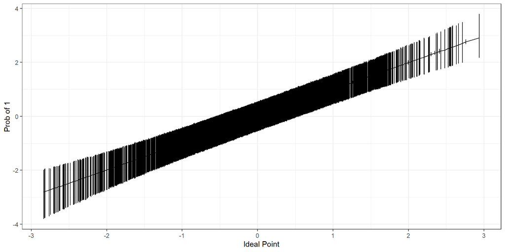

```r
# let's go with VCF9040, VCF0854, VCF9042
anes_VCF9040 = as.data.frame(mcmc_ANES[, grepl(colnames(mcmc_ANES), pattern = 'VCF9040')])
anes_VCF9040$variable = 'VCF9040'
colnames(anes_VCF9040) = c('lambda1', 'lambda2', 'gamma2', 'gamma3', 'gamma4', 'variable')
anes_VCF0854 = as.data.frame(mcmc_ANES[, grepl(colnames(mcmc_ANES), pattern = 'VCF0854')])
anes_VCF0854$variable = 'VCF0854'
colnames(anes_VCF0854) = c('lambda1', 'lambda2', 'gamma2', 'gamma3', 'gamma4', 'variable')
anes_VCF9042 = as.data.frame(mcmc_ANES[, grepl(colnames(mcmc_ANES), pattern = 'VCF9042')])
anes_VCF9042$variable = 'VCF9042'
colnames(anes_VCF9042) = c('lambda1', 'lambda2', 'gamma2', 'gamma3', 'gamma4', 'variable')
anes_sub = rbind(anes_VCF9040, anes_VCF0854, anes_VCF9042)

draws = summarize_draws(mcmc_ANES)

summary = draws %>%
  filter(grepl(variable, pattern = 'phi'))

ggplot(draws) +
  geom_errorbar(aes(x = mean, ymin = q5, ymax = q95)) +
  geom_line(aes(x = mean, y = median)) +
  theme_bw() +
  xlab('Ideal Point') +
  ylab('Prob of 1')
```

## Question 4

- *Recall our data on the ANES. For our purposes, use the following code to clean the data.* Done in pre-processing code, not shown above.
- *Given this data, please fit a 1D factor analytic model two ways*
  - *Using linear factor analysis (i.e. factanal)*
  - *Using emIRT. Note this requires you to have three categories for each question. Justify your decisions in order to put the ANES data into this form. You may find looking at the codebook for the ANES helpful (also on Canvas).*
- *Using the MCMC data on Canvas (i.e. mcmc_ANES_fa.RDS), please compare the ideal points between all three methods. Comment on what you see.*

Using 1D factor analysis:

```r
fa_ANES = factanal(selected_ANES, factors = 1)
fa_ANES$loadings
```

```
##
## Loadings:
##          Factor1
## VCF0853  -0.570
## VCF0878   0.434
## VCF0838  -0.473
## VCF0886   0.510
## VCF9048   0.264
## VCF0854   0.487
## VCF0887   0.485
## VCF0888  -0.155
## VCF0876a  0.465
## VCF0852   0.437
## VCF9040  -0.693
## VCF0894   0.564
## VCF0850  -0.425
## VCF0890   0.393
## VCF0876   0.416
## VCF9039   0.644
## VCF9047   0.537
## VCF9041  -0.657
## VCF9042   0.686
## VCF9049   0.148
##
##                Factor1
## SS loadings      4.905
## Proportion Var   0.245
```

Using emIRT (have to prep for the model a bit by recoding the questions based on the codebook - emIRT wants 0, 1, or -1):

```r
# prep

# VCF0853: emphasis on traditional values
selected_ANES$VCF0853[selected_ANES$VCF0853 == 2] = 1
selected_ANES$VCF0853[selected_ANES$VCF0853 == 4] = -1
selected_ANES$VCF0853[selected_ANES$VCF0853 == 5] = -1
selected_ANES$VCF0853[selected_ANES$VCF0853 == 3] = 0
selected_ANES$VCF0853[selected_ANES$VCF0853 == 8] = 0

# VCF0878: gays/lesbians adopt children
selected_ANES$VCF0878[selected_ANES$VCF0878 == 5] = -1
selected_ANES$VCF0878[selected_ANES$VCF0878 == 8] = 0

# VCF0838: when should abortion be allowed
# basically grouped this to say 1 is any option that isn't never
  # and -1 is option that is never
selected_ANES$VCF0838[selected_ANES$VCF0838 == 1] = -1
selected_ANES$VCF0838[selected_ANES$VCF0838 == 2] = 1
selected_ANES$VCF0838[selected_ANES$VCF0838 == 3] = 1
selected_ANES$VCF0838[selected_ANES$VCF0838 == 4] = 1
selected_ANES$VCF0838[selected_ANES$VCF0838 == 5] = 1
selected_ANES$VCF0838[selected_ANES$VCF0838 == 9] = 0

# VCF0886: federal spending - poor people
# 1 is increased, -1 is same or decreased
selected_ANES$VCF0886[selected_ANES$VCF0886 == 2] = -1
selected_ANES$VCF0886[selected_ANES$VCF0886 == 3] = -1
selected_ANES$VCF0886[selected_ANES$VCF0886 == 8] = 0

# VCF9048: federal spending - space
# 1 is increased, -1 is same or decreased
selected_ANES$VCF9048[selected_ANES$VCF9048 == 2] = -1
selected_ANES$VCF9048[selected_ANES$VCF9048 == 3] = -1
selected_ANES$VCF9048[selected_ANES$VCF9048 == 7] = 0
selected_ANES$VCF9048[selected_ANES$VCF9048 == 8] = 0

# VCF0854: tolerance of moral standards
selected_ANES$VCF0854[selected_ANES$VCF0854 == 2] = 1
selected_ANES$VCF0854[selected_ANES$VCF0854 == 4] = -1
selected_ANES$VCF0854[selected_ANES$VCF0854 == 5] = -1
selected_ANES$VCF0854[selected_ANES$VCF0854 == 3] = 0
selected_ANES$VCF0854[selected_ANES$VCF0854 == 8] = 0

# VCF0887: federal spending - childcare
# 1 is increased, -1 is same or decreased
selected_ANES$VCF0887[selected_ANES$VCF0887 == 2] = -1
selected_ANES$VCF0887[selected_ANES$VCF0887 == 3] = -1
selected_ANES$VCF0887[selected_ANES$VCF0887 == 8] = 0
selected_ANES$VCF0887[selected_ANES$VCF0887 == 9] = 0

# VCF0888: federal spending - dealing with crime
# 1 is increased, -1 is same or decreased
selected_ANES$VCF0888[selected_ANES$VCF0888 == 2] = -1
selected_ANES$VCF0888[selected_ANES$VCF0888 == 3] = -1
selected_ANES$VCF0888[selected_ANES$VCF0888 == 8] = 0
selected_ANES$VCF0888[selected_ANES$VCF0888 == 9] = 0

# VCF0876a: protect homosexuals against discrimination
selected_ANES$VCF0876a[selected_ANES$VCF0876a == 2] = 1
selected_ANES$VCF0876a[selected_ANES$VCF0876a == 4] = -1
selected_ANES$VCF0876a[selected_ANES$VCF0876a == 5] = -1
selected_ANES$VCF0876a[selected_ANES$VCF0876a == 7] = 0
selected_ANES$VCF0876a[selected_ANES$VCF0876a == 9] = 0

# VCF0852: adjust view of moral behavior changes
selected_ANES$VCF0852[selected_ANES$VCF0852 == 2] = 1
selected_ANES$VCF0852[selected_ANES$VCF0852 == 4] = -1
selected_ANES$VCF0852[selected_ANES$VCF0852 == 5] = -1
selected_ANES$VCF0852[selected_ANES$VCF0852 == 3] = 0
selected_ANES$VCF0852[selected_ANES$VCF0852 == 8] = 0
selected_ANES$VCF0852[selected_ANES$VCF0852 == 9] = 0

# VCF9040: blacks should not have special favors
selected_ANES$VCF9040[selected_ANES$VCF9040 == 2] = 1
selected_ANES$VCF9040[selected_ANES$VCF9040 == 4] = -1
selected_ANES$VCF9040[selected_ANES$VCF9040 == 5] = -1
selected_ANES$VCF9040[selected_ANES$VCF9040 == 3] = 0
selected_ANES$VCF9040[selected_ANES$VCF9040 == 8] = 0
selected_ANES$VCF9040[selected_ANES$VCF9040 == 9] = 0

# VCF0894: federal spending - welfare programs
# 1 is increased, -1 is same or decreased
selected_ANES$VCF0894[selected_ANES$VCF0894 == 2] = -1
selected_ANES$VCF0894[selected_ANES$VCF0894 == 3] = -1
selected_ANES$VCF0894[selected_ANES$VCF0894 == 8] = 0
selected_ANES$VCF0894[selected_ANES$VCF0894 == 9] = 0

# VCF0850: authority of the bible 1984
# related to Gd = 1, otherwise -1
selected_ANES$VCF0850[selected_ANES$VCF0850 == 2] = 1
selected_ANES$VCF0850[selected_ANES$VCF0850 == 3] = -1
selected_ANES$VCF0850[selected_ANES$VCF0850 == 9] = 0

# VCF0890: federal spending - public schools
selected_ANES$VCF0890[selected_ANES$VCF0890 == 2] = -1
selected_ANES$VCF0890[selected_ANES$VCF0890 == 3] = -1
selected_ANES$VCF0890[selected_ANES$VCF0890 == 8] = 0
selected_ANES$VCF0890[selected_ANES$VCF0890 == 9] = 0

# VCF0876: protect homosexuals against discrimination
selected_ANES$VCF0876[selected_ANES$VCF0876 == 5] = -1
selected_ANES$VCF0876[selected_ANES$VCF0876 == 8] = 0
selected_ANES$VCF0876[selected_ANES$VCF0876 == 8] = 0

# VCF9039: conditions make it difficult for blacks to succeed
selected_ANES$VCF9039[selected_ANES$VCF9039 == 2] = 1
selected_ANES$VCF9039[selected_ANES$VCF9039 == 4] = -1
selected_ANES$VCF9039[selected_ANES$VCF9039 == 5] = -1
selected_ANES$VCF9039[selected_ANES$VCF9039 == 3] = 0
selected_ANES$VCF9039[selected_ANES$VCF9039 == 8] = 0
selected_ANES$VCF9039[selected_ANES$VCF9039 == 9] = 0

# VCF9047: federal spending - environment
# 1 is increased, -1 is same or decreased
selected_ANES$VCF9047[selected_ANES$VCF9047 == 2] = -1
selected_ANES$VCF9047[selected_ANES$VCF9047 == 3] = -1
selected_ANES$VCF9047[selected_ANES$VCF9047 == 7] = 0
selected_ANES$VCF9047[selected_ANES$VCF9047 == 8] = 0
selected_ANES$VCF9047[selected_ANES$VCF9047 == 9] = 0

# VCF9041: blacks must try harder to succeed
selected_ANES$VCF9041[selected_ANES$VCF9041 == 2] = 1
selected_ANES$VCF9041[selected_ANES$VCF9041 == 4] = -1
selected_ANES$VCF9041[selected_ANES$VCF9041 == 5] = -1
selected_ANES$VCF9041[selected_ANES$VCF9041 == 3] = 0
selected_ANES$VCF9041[selected_ANES$VCF9041 == 8] = 0
selected_ANES$VCF9041[selected_ANES$VCF9041 == 9] = 0

# VCF9042: blacks less than they deserve
selected_ANES$VCF9042[selected_ANES$VCF9042 == 2] = 1
selected_ANES$VCF9042[selected_ANES$VCF9042 == 4] = -1
selected_ANES$VCF9042[selected_ANES$VCF9042 == 5] = -1
selected_ANES$VCF9042[selected_ANES$VCF9042 == 3] = 0
selected_ANES$VCF9042[selected_ANES$VCF9042 == 8] = 0
selected_ANES$VCF9042[selected_ANES$VCF9042 == 9] = 0

# VCF9049: federal spending - social security
# 1 is increased, -1 is same or decreased
selected_ANES$VCF9049[selected_ANES$VCF9049 == 2] = -1
selected_ANES$VCF9049[selected_ANES$VCF9049 == 3] = -1
selected_ANES$VCF9049[selected_ANES$VCF9049 == 7] = 0
selected_ANES$VCF9049[selected_ANES$VCF9049 == 8] = 0
selected_ANES$VCF9049[selected_ANES$VCF9049 == 9] = 0

ANES_mat = as.matrix(selected_ANES)
```

```r
# setup for the model
start2 = list(
  alpha = matrix(rnorm(ncol(ANES_mat))),
  beta = matrix(rnorm(ncol(ANES_mat))),
  x = matrix(rnorm(nrow(ANES_mat)))
)

prior2 = list(
  x = list(mu = matrix(0), sigma = matrix(1)),
  beta = list(mu = matrix(c(0,0)), sigma = 25 * diag(2))
)

# fit the model
fit_bin_emIRT2 = binIRT(
  .rc = list(votes = ANES_mat),
  .starts = start2,
  .priors = prior2,
  .control = list(verbose = FALSE, thresh = 1e-6)
)
```

```
##
## ====================
## binIRT: Binary IRT via Expectation Maximization
##
##  Done in 71 iterations, using 1 threads.
## ====================
```

```r
dim(ANES_mat)
```

```
## [1] 3382   20
```

```r
dim(fit_bin_emIRT2$means$x)
```

```
## [1] 3382    1
```

```r
dim(fit_bin_emIRT2$means$beta)
```

```
## [1] 20  2
```

```r
em.out = c(t(fit_bin_emIRT2$means$x))
em.out[em.out == 0] = NA
em.out = na.omit(em.out)
```

From what I understand, the means$x values are the ideal points from the emIRT model.

Using MCMC data, and compare methods.

```r
summary_FA = summarize_draws(mcmc_ANES)
range(summary_FA$rhat, na.rm = TRUE)
```

```
## [1] 0.9997501 1.0032865
```

```r
summary_FA %>%
  filter(grepl(variable, pattern = '^phi')) %>%
  dim
```

```
## [1] 3382   10
```

Looked at the dynIRT documentation and I think I’m right on the edge of doing this but I’m not entirely sure how to compare - for the first model, I have the loadings. For the emIRT model, I have the ideal points (mean$x). If I could figure out how to get the loadings from the ideal points of the other two models, I could compare with correlation, as is done in the dynIRT documentation - couldn’t quite get there.

## Question 5

- *Please design a complex IRT that might be useful to a question that you are interested in studying. This could involve some type of outcome that we did not discuss in class or some complex generative model in the style of Rosas et al. (2015).*
- *You are not required to estimate this model, but try to describe the scenario as precisely as possible.*
- *You may find it useful to write down the model with a likelihood notation or generative model.*

Stemming from the Rosas et al. paper, I wonder if there is a way to use roll-call data from when congressmen do respond to suggest a probability of not responding based on the topic? It seems like to go the other direction we can follow methods we’ve learned so far, which is to say we can use ideal points and calculations from roll-call votes that WERE answered to find the probabilities of responding ‘yea’ where there is no response. But can we go the other direction? If representatives are not responding for reason (and after living on the Hill for 3 years and watching West Wing many times through I’d suggest there are votes where abstaining has more of an impact than voting ‘yea’ or ‘nay’), can we use ideal points from the votes where they are responding to find the probability that, based on the topic (or other things, such as indicators of tight re-election races, running for president, other factors), they will abstain? Further, are we able to determine the difference between abstaining and not voting?